# An Approximate Fuzzy Knowledge Based Systems Reasoning Model for Situation and Threat Assessment

| Author | Professor | Institution |
| --- | --- | --- |
| OCdt Syed A.M. | Dr. Yawei Liang | Royal Military College Canada |

This lab develops a compact Fuzzy Knowledge-Based System (FKBS) to support situational and threat assessment for a naval task group operating in a littoral environment.

In the process of situation and threat assessment, the following 18 parameters are normally taken into account:

| No. | Evidence | Details |
| --- | --- | --- |
| 01 | Origin | Country of origin. Higher threat if from a hostile nation. (`H` = Hostile, `N` = Neutral, `F` = Friendly) |
| 02 | IFF Mode | Identification Friend or Foe mode: 1–2 (military), 3/A & C (civilian), 4 (encrypted/military). |
| 03 | Intel | Additional intelligence indicators or reports that may increase threat. |
| 04 | Air Route | Whether the contact is inside a commercial air corridor (`ON`) or not (`OFF`). |
| **05** | **Altitude** | **Altitude of the contact in feet.** |
| 06 | ESM | Electronic Support Measures (signals/intercepts indicating intent or capability). |
| **07** | **Speed** | **Speed in knots (nautical miles per hour).** |
| **08** | **CAP** | **Closest Point of Approach — how close the contact will pass the own ship (nm).** |
| 09 | Feet | Terrain type beneath the contact: `Wet` = over water, `Dry` = over land. |
| 10 | Number | Number of contacts in the formation. |
| 11 | Coord Act | Coordinated act — whether the contact is coordinating actions with others. |
| 12 | Manvr | Manoeuvre — the way the contact is flying (evasive, attack profile, loitering, etc.). |
| 13 | Wings | Whether the contact carries ordnance under its wings. |
| 14 | Heading | Bearing relative to the task group: `Close` = flying toward TG, `Away` = flying away. |
| **15** | **Range** | **Distance between the contact and the task group (nautical miles).** |
| 16 | Own Supt | Own support — proximity of friendly ships and/or aircraft. |
| 17 | Vis | Visibility (distance) and prevailing environmental conditions. |
| 18 | Wpn Envl | Weapon envelope — whether the contact is within effective weapon release ranges (R-min to R-max). |

The exercise focuses on modelling uncertainty in four key numeric evidences (altitude, speed, closest point of approach, and range), designing membership functions, encoding human expert rules, and producing a continuous threat rating for each contact to aid operator decision-making.

```python
%matplotlib inline
%config InlineBackend.figure_format = 'retina'
import matplotlib.pyplot as plt
import numpy as np
import skfuzzy as fuzz
import pandas as pd
from sklearn.impute import KNNImputer
from skfuzzy import control as ctrl
```

## Membership Functions - Input

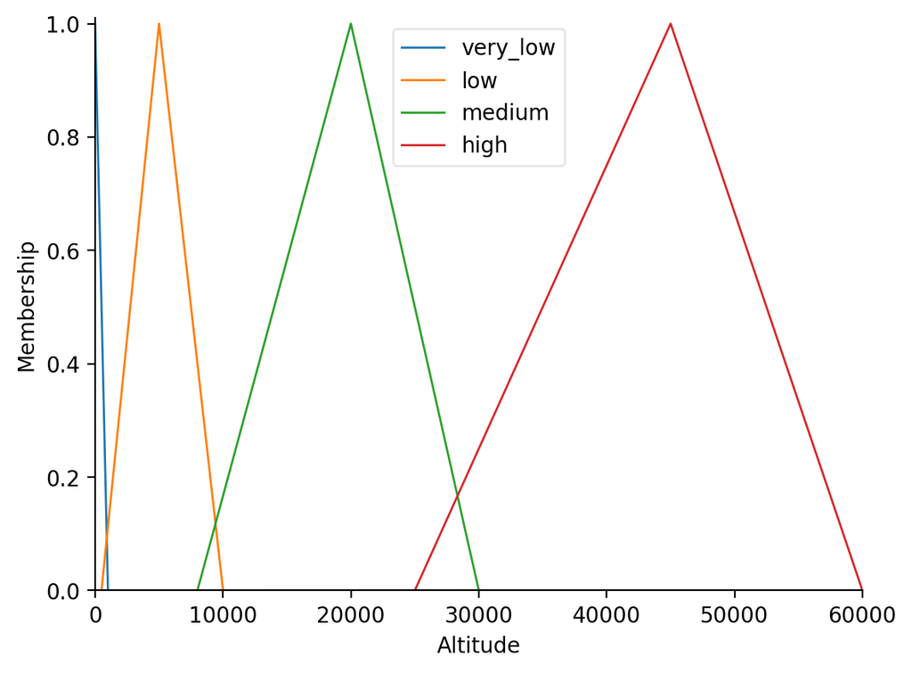

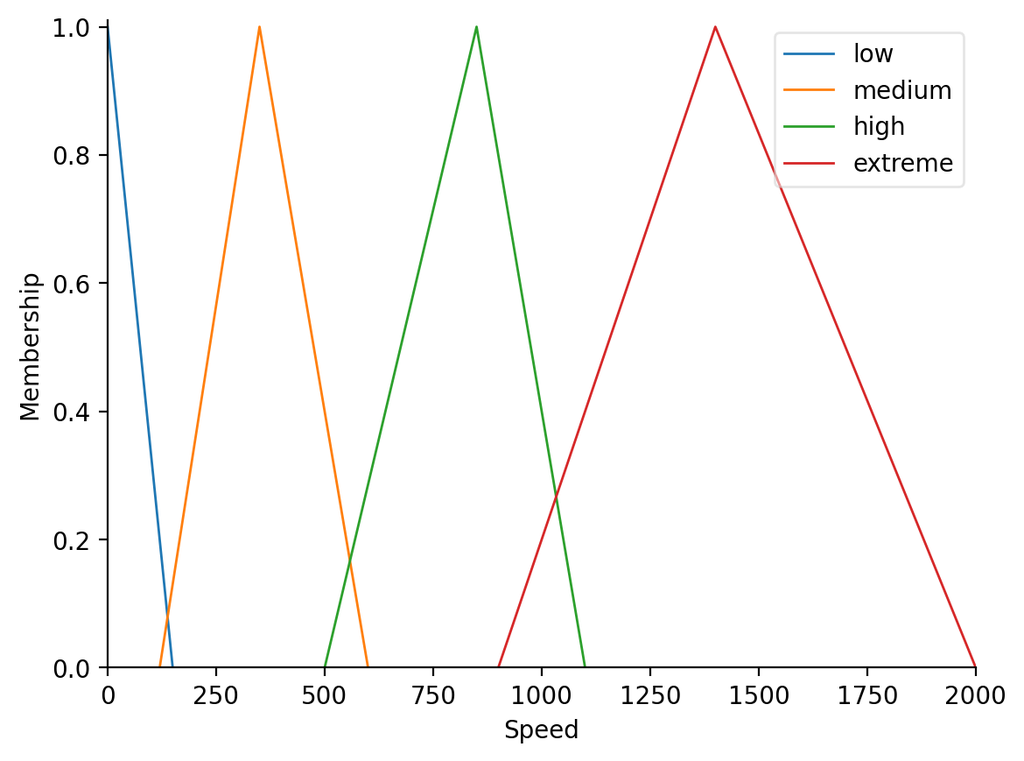

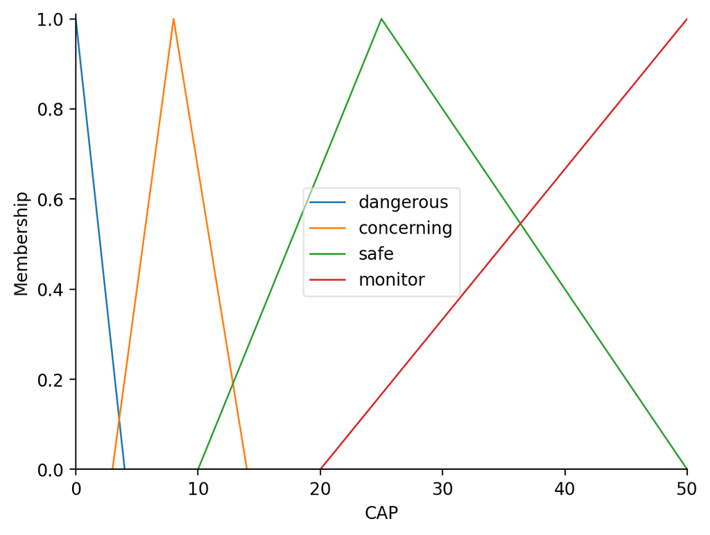

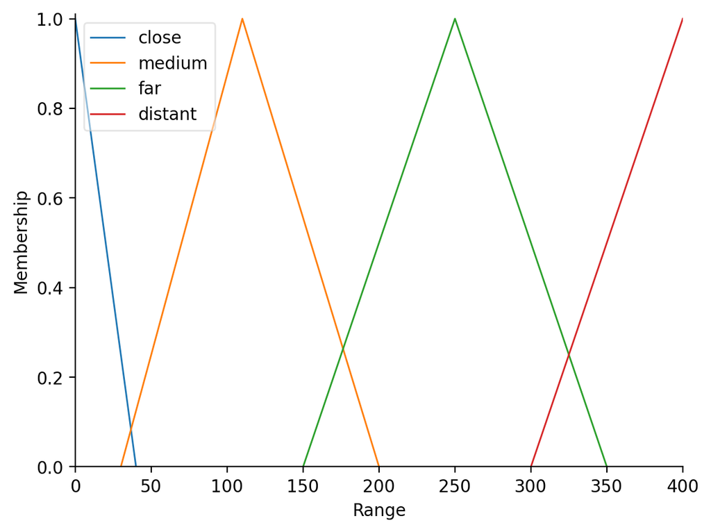

```python
# Altitude in feet (using generalized bell MFs)
Altitude = ctrl.Antecedent(np.arange(0, 60001, 1), "Altitude")
Altitude["very_low"] = fuzz.trimf(Altitude.universe, [0, 0, 1000])
Altitude["low"] = fuzz.trimf(Altitude.universe, [500, 5000, 10000])
Altitude["medium"] = fuzz.trimf(Altitude.universe, [8000, 20000, 30000])
Altitude["high"] = fuzz.trimf(Altitude.universe, [25000, 45000, 60000])

# Speed in knots (0–2000)
Speed = ctrl.Antecedent(np.arange(0, 2001, 1), "Speed")
Speed["low"] = fuzz.trimf(Speed.universe, [0, 0, 150])  # drones/rotary very low
Speed["medium"] = fuzz.trimf(Speed.universe, [120, 350, 600])  # transports/civilians
Speed["high"] = fuzz.trimf(Speed.universe, [500, 850, 1100])  # fighters/bombers
Speed["extreme"] = fuzz.trimf(
    Speed.universe, [900, 1400, 2000]
)  # missiles/hypersonic (narrower left edge)

# Closest Point of Approach (CPA) in nm (0–50)
CAP = ctrl.Antecedent(np.arange(0, 51, 1), "CAP")
CAP["dangerous"] = fuzz.trimf(CAP.universe, [0, 0, 4])  # < ~4nm very dangerous
CAP["concerning"] = fuzz.trimf(CAP.universe, [3, 8, 14])
CAP["safe"] = fuzz.trimf(CAP.universe, [10, 25, 50])
CAP["monitor"] = fuzz.trimf(CAP.universe, [20, 50, 80])

# Range in nm (0–400)
Range = ctrl.Antecedent(np.arange(0, 401, 1), "Range")
Range["close"] = fuzz.trimf(Range.universe, [0, 0, 40])  # immediate <~40nm
Range["medium"] = fuzz.trimf(Range.universe, [30, 110, 200])
Range["far"] = fuzz.trimf(Range.universe, [150, 250, 350])
Range["distant"] = fuzz.trimf(Range.universe, [300, 400, 600])


Altitude.view()
Speed.view()
CAP.view()
Range.view()
plt.show()
```

### Output

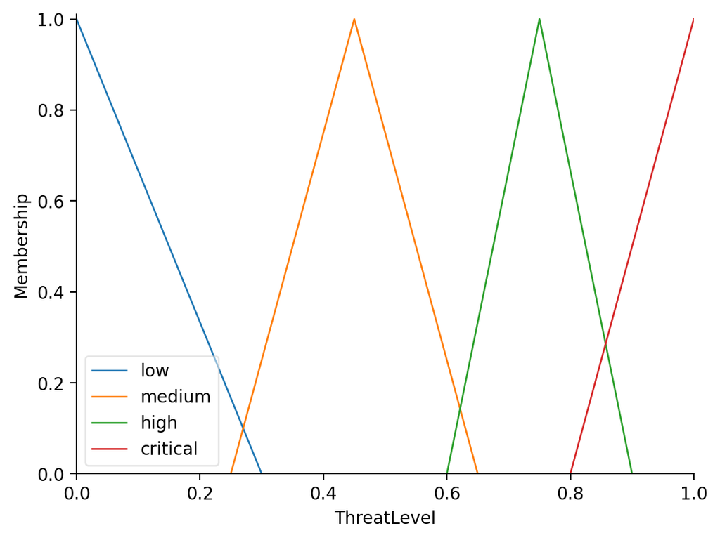

```python
ThreatLevel = ctrl.Consequent(np.arange(0, 1.01, 0.01), "ThreatLevel")
ThreatLevel["low"] = fuzz.trimf(ThreatLevel.universe, [0, 0, 0.3])
ThreatLevel["medium"] = fuzz.trimf(ThreatLevel.universe, [0.25, 0.45, 0.65])
ThreatLevel["high"] = fuzz.trimf(ThreatLevel.universe, [0.6, 0.75, 0.9])
ThreatLevel["critical"] = fuzz.trimf(ThreatLevel.universe, [0.8, 1, 1])

ThreatLevel.view()
plt.show()
```

## Inference Rules

The fuzzy rule base is designed to capture **realistic air and missile threats** to a task group.  
It considers **altitude, speed, range, and closest point of approach (CPA)**.

Key Threat Categories include:

- Sea-skimming missiles **(Critical Threat)**
  - Very low altitude, extreme speed, close range, dangerous CPA.
- Bombers / Strike Aircraft **(High Threat)**
  - Medium altitude, high speed, medium range.
- Civilian Airliners **(Low Threat)**
  - Medium altitude, medium speed, distant range.
- Recon / High-Altitude Craft **(Medium Threat)**
  - High altitude, high speed, far range.

```python
rules = []

# Missiles (sea-skimmer or hypersonic)
rules.append(
    ctrl.Rule(
        antecedent=Altitude["very_low"] & Speed["extreme"] & CAP["dangerous"],
        consequent=ThreatLevel["critical"],
    )
)
rules.append(
    ctrl.Rule(
        antecedent=Speed["extreme"] & Range["medium"],
        consequent=ThreatLevel["critical"],
    )
)
rules.append(
    ctrl.Rule(
        antecedent=Speed["extreme"] & Range["distant"], consequent=ThreatLevel["high"]
    )
)

# Strike fighters / bombers
rules.append(
    ctrl.Rule(
        antecedent=Altitude["low"] & Speed["high"] & CAP["dangerous"],
        consequent=ThreatLevel["high"],
    )
)
rules.append(
    ctrl.Rule(
        antecedent=Altitude["medium"]
        & Speed["high"]
        & Range["medium"]
        & CAP["concerning"],
        consequent=ThreatLevel["high"],
    )
)

# Recon / high flyers
rules.append(
    ctrl.Rule(
        antecedent=Altitude["high"] & Speed["high"] & Range["far"],
        consequent=ThreatLevel["medium"],
    )
)
rules.append(
    ctrl.Rule(
        antecedent=Altitude["high"] & Speed["medium"] & Range["distant"],
        consequent=ThreatLevel["low"],
    )
)

# Civilian profiles
rules.append(
    ctrl.Rule(
        antecedent=Altitude["medium"]
        & Speed["medium"]
        & Range["distant"]
        & CAP["safe"],
        consequent=ThreatLevel["low"],
    )
)

# Drones / rotary
rules.append(
    ctrl.Rule(
        antecedent=Altitude["low"] & Speed["low"] & Range["close"],
        consequent=ThreatLevel["medium"],
    )
)

# Overrides to force certain obvious values for certain conditions
rules.append(
    ctrl.Rule(
        antecedent=Range["close"] & CAP["dangerous"], consequent=ThreatLevel["critical"]
    )
)
rules.append(
    ctrl.Rule(
        antecedent=Range["medium"] & CAP["concerning"], consequent=ThreatLevel["high"]
    )
)
rules.append(
    ctrl.Rule(antecedent=Range["far"] & CAP["safe"], consequent=ThreatLevel["low"])
)

rules.append(
    ctrl.Rule(
        Altitude["low"] & Speed["low"] & Range["close"] & CAP["concerning"],
        ThreatLevel["medium"],
    )
)

# if drone is extremely close + dangerous CPA, escalate to HIGH (local safety)
rules.append(
    ctrl.Rule(
        Altitude["low"] & Speed["low"] & Range["close"] & CAP["dangerous"],
        ThreatLevel["high"],
    )
)

# --- Hypersonic/missile rules: extreme speed escalates to CRITICAL as range reduces
rules.append(
    ctrl.Rule(
        Speed["extreme"] & (Range["medium"] | Range["close"]) & CAP["concerning"],
        ThreatLevel["critical"],
    )
)

# Hypersonic at long range is high (early warning) but not ignored
rules.append(ctrl.Rule(Speed["extreme"] & Range["far"], ThreatLevel["high"]))
```

```python
"""
    Control System
"""
ThreatLevelSimulation = ctrl.ControlSystemSimulation(ctrl.ControlSystem(rules))
```

### Testing the FKBS Model

```python
type feet = int
type knots = int
type nautical_miles = int
type threat_rating = int


def SimulateThreatRating(
    altitude: feet,
    speed: knots,
    closest_approach_point: nautical_miles,
    range: nautical_miles,
) -> threat_rating:
    ThreatLevelSimulation.input["Altitude"] = altitude
    ThreatLevelSimulation.input["Speed"] = speed
    ThreatLevelSimulation.input["CAP"] = closest_approach_point
    ThreatLevelSimulation.input["Range"] = range
    ThreatLevelSimulation.compute()

    return ThreatLevelSimulation.output["ThreatLevel"]


def get_threat_label_fuzzy(value):
    memberships = {
        "LOW": fuzz.interp_membership(
            ThreatLevel.universe, ThreatLevel["low"].mf, value
        ),
        "MEDIUM": fuzz.interp_membership(
            ThreatLevel.universe, ThreatLevel["medium"].mf, value
        ),
        "HIGH": fuzz.interp_membership(
            ThreatLevel.universe, ThreatLevel["high"].mf, value
        ),
        "CRITICAL": fuzz.interp_membership(
            ThreatLevel.universe, ThreatLevel["critical"].mf, value
        ),
    }
    return max(memberships, key=memberships.get)  # pick label with max membership
```

#### Simulated Realtime Examples

```python
def ShowSimulatedThreatRating(name: str, csv_name: str):
    # Read data
    track_data = pd.read_csv(csv_name)

    # Safe simulation: return NaN on error or non-finite result
    def safe_simulate_nan(row):
        try:
            v = SimulateThreatRating(
                row["Altitude_ft"], row["Speed_kts"], row["CAP_nm"], row["Range_nm"]
            )
            return float(v) if (v is not None and np.isfinite(v)) else np.nan
        except Exception:
            return np.nan

    track_data["ThreatRating"] = track_data.apply(safe_simulate_nan, axis=1)

    # Numeric columns used for imputation
    numeric_cols = ["Altitude_ft", "Speed_kts", "CAP_nm", "Range_nm", "ThreatRating"]
    missing_cols = [c for c in numeric_cols if c not in track_data.columns]
    if missing_cols:
        raise KeyError(f"Missing columns in {csv_name}: {missing_cols}")

    df_num = track_data[numeric_cols].astype(float).copy()
    n_samples = len(df_num)

    # Fill entirely-NaN columns with 0.0
    all_nan_cols = df_num.columns[df_num.isna().all()].tolist()
    if all_nan_cols:
        df_num[all_nan_cols] = df_num[all_nan_cols].fillna(0.0)

    # Impute remaining NaNs: median fill for tiny sample, else KNNImputer
    if df_num.isna().any().any():
        if n_samples < 2:
            df_num = df_num.fillna(df_num.median().fillna(0.0))
        else:
            imputer = KNNImputer(n_neighbors=min(3, max(1, n_samples - 1)))
            arr_imputed = imputer.fit_transform(df_num.values)
            df_num = pd.DataFrame(arr_imputed, columns=numeric_cols, index=df_num.index)

    # Ensure ThreatRating numeric and clipped to [0,1]
    track_data["ThreatRating"] = (
        pd.to_numeric(df_num["ThreatRating"], errors="coerce")
        .fillna(0.0)
        .clip(0.0, 1.0)
    )

    # Map numeric -> label (try fuzzy mapper, else threshold fallback)
    def map_label(value):
        try:
            return get_threat_label_fuzzy(value, ThreatLevel)
        except Exception:
            if value <= 0.3:
                return "LOW"
            if value <= 0.6:
                return "MEDIUM"
            if value <= 0.85:
                return "HIGH"
            return "CRITICAL"

    track_data["ThreatLevel"] = track_data["ThreatRating"].apply(map_label)

    def safe_norm(col):
        mx = track_data[col].max()
        return track_data[col] / (mx if (mx and np.isfinite(mx)) else 1.0)

    alt_norm = safe_norm("Altitude_ft")
    speed_norm = safe_norm("Speed_kts")
    cap_norm = safe_norm("CAP_nm")
    range_norm = safe_norm("Range_nm")

    plt.figure(figsize=(12, 6))
    plt.plot(
        track_data["time"],
        track_data["ThreatRating"],
        marker="o",
        linestyle="-",
        label="ThreatRating",
    )
    plt.plot(
        track_data["time"],
        alt_norm,
        marker="x",
        linestyle="--",
        label="Altitude (normalized)",
    )
    plt.plot(
        track_data["time"],
        speed_norm,
        marker="s",
        linestyle="--",
        label="Speed (normalized)",
    )
    plt.plot(
        track_data["time"],
        cap_norm,
        marker="^",
        linestyle="--",
        label="CAP (normalized)",
    )
    plt.plot(
        track_data["time"],
        range_norm,
        marker="d",
        linestyle="--",
        label="Range (normalized)",
    )

    for t, val, label in zip(
        track_data["time"], track_data["ThreatRating"], track_data["ThreatLevel"]
    ):
        y = float(val) + 0.05
        if y > 1.05:
            y = float(val) - 0.06
        plt.text(t, y, label, ha="center", fontsize=8, color="red")

    plt.title(f"Threat and Inputs over Time for {name}")
    plt.xlabel("Time")
    plt.ylabel("Normalized Values / ThreatRating")
    plt.ylim(0, 1.15)
    plt.grid(True)
    plt.legend()
    plt.show()

    return track_data
```

### Sea-skimming missile: Critical

Very low, extreme speed, tiny CPA, closes fast (hardest threat to detect/react).

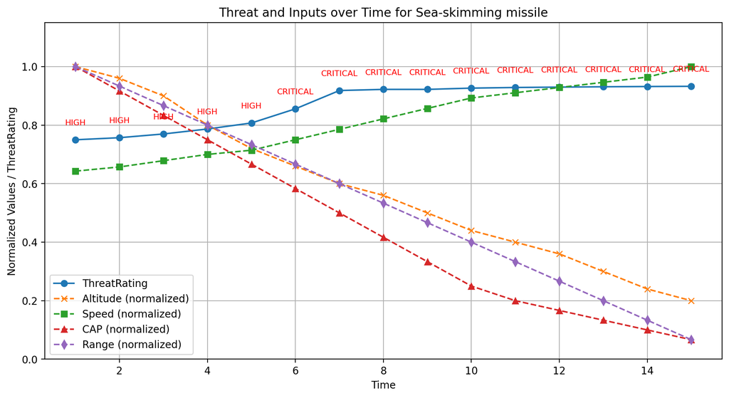

|  | time | Altitude_ft | Speed_kts | CAP_nm | Range_nm | ThreatRating | ThreatLevel |
| --- | --- | --- | --- | --- | --- | --- | --- |
| 0 | 1 | 50 | 900 | 6.0 | 150 | 0.750000 | HIGH |
| 1 | 2 | 48 | 920 | 5.5 | 140 | 0.757107 | HIGH |
| 2 | 3 | 45 | 950 | 5.0 | 130 | 0.769844 | HIGH |
| 3 | 4 | 40 | 980 | 4.5 | 120 | 0.786854 | HIGH |
| 4 | 5 | 36 | 1000 | 4.0 | 110 | 0.807403 | HIGH |
| 5 | 6 | 33 | 1050 | 3.5 | 100 | 0.855760 | CRITICAL |
| 6 | 7 | 30 | 1100 | 3.0 | 90 | 0.918333 | CRITICAL |
| 7 | 8 | 28 | 1150 | 2.5 | 80 | 0.922222 | CRITICAL |
| 8 | 9 | 25 | 1200 | 2.0 | 70 | 0.922222 | CRITICAL |
| 9 | 10 | 22 | 1250 | 1.5 | 60 | 0.926515 | CRITICAL |
| 10 | 11 | 20 | 1275 | 1.2 | 50 | 0.928718 | CRITICAL |
| 11 | 12 | 18 | 1300 | 1.0 | 40 | 0.930000 | CRITICAL |
| 12 | 13 | 15 | 1325 | 0.8 | 30 | 0.931111 | CRITICAL |
| 13 | 14 | 12 | 1350 | 0.6 | 20 | 0.932029 | CRITICAL |
| 14 | 15 | 10 | 1400 | 0.4 | 10 | 0.932727 | CRITICAL |

```python
ShowSimulatedThreatRating("Sea-skimming missile", "examples/sea_skimmer.csv")
```

### Strike Fighter: High

Low altitude, high speed, inbound, within weapons release range.

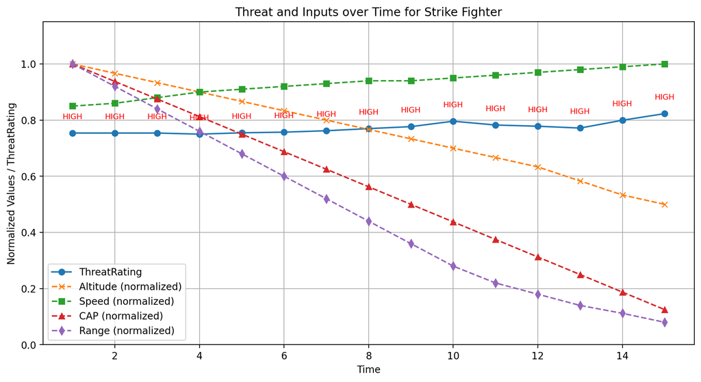

|  | time | Altitude_ft | Speed_kts | CAP_nm | Range_nm | ThreatRating | ThreatLevel |
| --- | --- | --- | --- | --- | --- | --- | --- |
| 0 | 1 | 6000 | 850 | 8.0 | 250 | 0.753987 | HIGH |
| 1 | 2 | 5800 | 860 | 7.5 | 230 | 0.753987 | HIGH |
| 2 | 3 | 5600 | 880 | 7.0 | 210 | 0.753987 | HIGH |
| 3 | 4 | 5400 | 900 | 6.5 | 190 | 0.750000 | HIGH |
| 4 | 5 | 5200 | 910 | 6.0 | 170 | 0.754854 | HIGH |
| 5 | 6 | 5000 | 920 | 5.5 | 150 | 0.757107 | HIGH |
| 6 | 7 | 4800 | 930 | 5.0 | 130 | 0.762160 | HIGH |
| 7 | 8 | 4600 | 940 | 4.5 | 110 | 0.769726 | HIGH |
| 8 | 9 | 4400 | 940 | 4.0 | 90 | 0.776823 | HIGH |
| 9 | 10 | 4200 | 950 | 3.5 | 70 | 0.796058 | HIGH |
| 10 | 11 | 4000 | 960 | 3.0 | 55 | 0.782538 | HIGH |
| 11 | 12 | 3800 | 970 | 2.5 | 45 | 0.778193 | HIGH |
| 12 | 13 | 3500 | 980 | 2.0 | 35 | 0.771708 | HIGH |
| 13 | 14 | 3200 | 990 | 1.5 | 28 | 0.799502 | HIGH |
| 14 | 15 | 3000 | 1000 | 1.0 | 20 | 0.823114 | HIGH |

```python
ShowSimulatedThreatRating("Strike Fighter", "examples/strike_fighter.csv")
```

### Civilian Airliner: Low

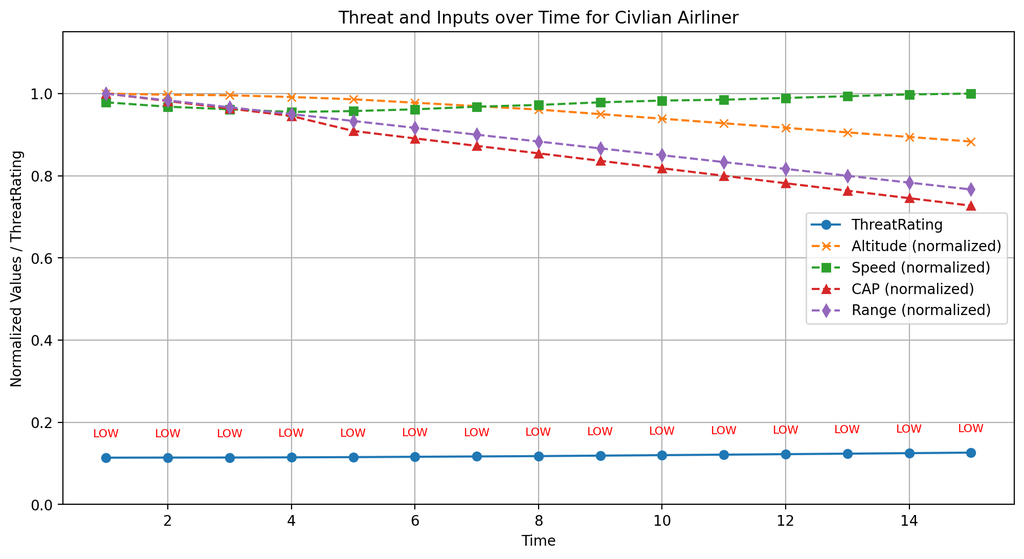

|  | time | Altitude_ft | Speed_kts | CAP_nm | Range_nm | ThreatRating | ThreatLevel |
| --- | --- | --- | --- | --- | --- | --- | --- |
| 0 | 1 | 36000 | 460 | 55 | 600 | 0.113966 | LOW |
| 1 | 2 | 35900 | 455 | 54 | 590 | 0.114229 | LOW |
| 2 | 3 | 35850 | 452 | 53 | 580 | 0.114361 | LOW |
| 3 | 4 | 35700 | 449 | 52 | 570 | 0.114759 | LOW |
| 4 | 5 | 35500 | 450 | 50 | 560 | 0.115297 | LOW |
| 5 | 6 | 35200 | 452 | 49 | 550 | 0.116114 | LOW |
| 6 | 7 | 34900 | 455 | 48 | 540 | 0.116945 | LOW |
| 7 | 8 | 34600 | 457 | 47 | 530 | 0.117789 | LOW |
| 8 | 9 | 34200 | 460 | 46 | 520 | 0.118935 | LOW |
| 9 | 10 | 33800 | 462 | 45 | 510 | 0.120103 | LOW |
| 10 | 11 | 33400 | 463 | 44 | 500 | 0.121291 | LOW |
| 11 | 12 | 33000 | 465 | 43 | 490 | 0.122500 | LOW |
| 12 | 13 | 32600 | 467 | 42 | 480 | 0.123728 | LOW |
| 13 | 14 | 32200 | 469 | 41 | 470 | 0.124976 | LOW |
| 14 | 15 | 31800 | 470 | 40 | 460 | 0.126241 | LOW |

```python
ShowSimulatedThreatRating("Civlian Airliner", "examples/airliner.csv")
```

### High Altitude Recon Aircraft: Medium

High altitude, high speed, but distant with larger CPA → monitor, not immediate.

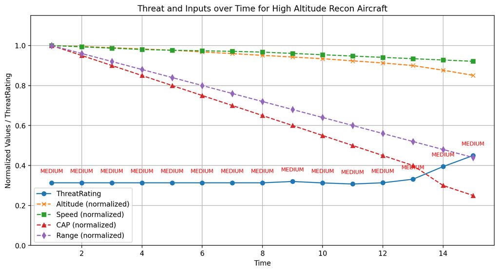

|  | time | Altitude_ft | Speed_kts | CAP_nm | Range_nm | ThreatRating | ThreatLevel |
| --- | --- | --- | --- | --- | --- | --- | --- |
| 0 | 1 | 47000 | 760 | 40 | 500 | 0.313467 | MEDIUM |
| 1 | 2 | 46800 | 755 | 38 | 480 | 0.313467 | MEDIUM |
| 2 | 3 | 46500 | 750 | 36 | 460 | 0.313467 | MEDIUM |
| 3 | 4 | 46200 | 745 | 34 | 440 | 0.313467 | MEDIUM |
| 4 | 5 | 45900 | 742 | 32 | 420 | 0.313467 | MEDIUM |
| 5 | 6 | 45500 | 740 | 30 | 400 | 0.313467 | MEDIUM |
| 6 | 7 | 45100 | 738 | 28 | 380 | 0.313467 | MEDIUM |
| 7 | 8 | 44700 | 735 | 26 | 360 | 0.313467 | MEDIUM |
| 8 | 9 | 44300 | 730 | 24 | 340 | 0.320026 | MEDIUM |
| 9 | 10 | 43900 | 725 | 22 | 320 | 0.312907 | MEDIUM |
| 10 | 11 | 43400 | 720 | 20 | 300 | 0.307468 | MEDIUM |
| 11 | 12 | 42900 | 715 | 18 | 280 | 0.313607 | MEDIUM |
| 12 | 13 | 42300 | 710 | 16 | 260 | 0.331460 | MEDIUM |
| 13 | 14 | 41200 | 705 | 12 | 240 | 0.394527 | MEDIUM |
| 14 | 15 | 40000 | 700 | 10 | 220 | 0.450000 | MEDIUM |

```python
ShowSimulatedThreatRating("High Altitude Recon Aircraft", "examples/recon_high.csv")
```

### Drone: Medium

Low altitude, slow, close proximity → not lethal but proximity = concern.

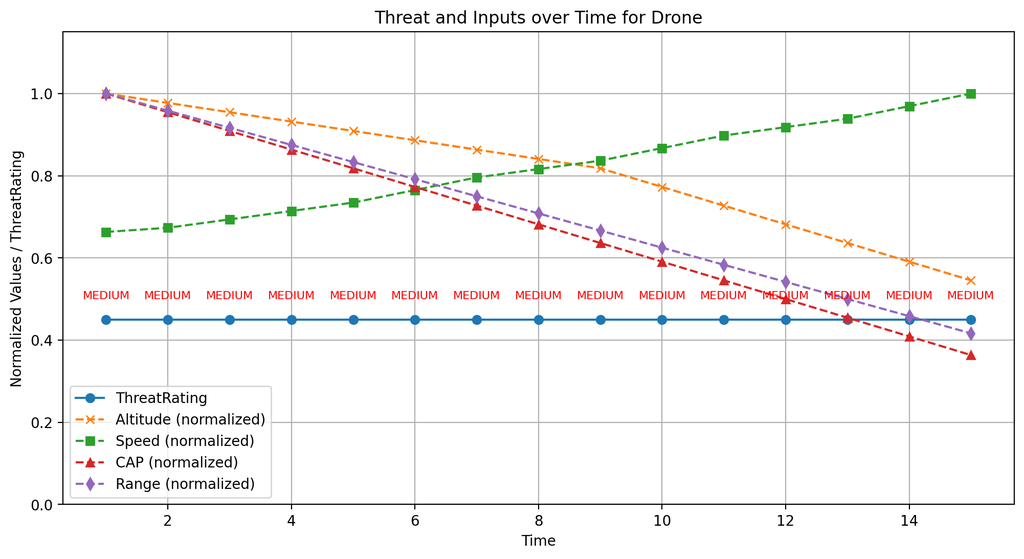

|  | time | Altitude_ft | Speed_kts | CAP_nm | Range_nm | ThreatRating | ThreatLevel |
| --- | --- | --- | --- | --- | --- | --- | --- |
| 0 | 1 | 2200 | 65 | 11.0 | 24 | 0.45 | MEDIUM |
| 1 | 2 | 2150 | 66 | 10.5 | 23 | 0.45 | MEDIUM |
| 2 | 3 | 2100 | 68 | 10.0 | 22 | 0.45 | MEDIUM |
| 3 | 4 | 2050 | 70 | 9.5 | 21 | 0.45 | MEDIUM |
| 4 | 5 | 2000 | 72 | 9.0 | 20 | 0.45 | MEDIUM |
| 5 | 6 | 1950 | 75 | 8.5 | 19 | 0.45 | MEDIUM |
| 6 | 7 | 1900 | 78 | 8.0 | 18 | 0.45 | MEDIUM |
| 7 | 8 | 1850 | 80 | 7.5 | 17 | 0.45 | MEDIUM |
| 8 | 9 | 1800 | 82 | 7.0 | 16 | 0.45 | MEDIUM |
| 9 | 10 | 1700 | 85 | 6.5 | 15 | 0.45 | MEDIUM |
| 10 | 11 | 1600 | 88 | 6.0 | 14 | 0.45 | MEDIUM |
| 11 | 12 | 1500 | 90 | 5.5 | 13 | 0.45 | MEDIUM |
| 12 | 13 | 1400 | 92 | 5.0 | 12 | 0.45 | MEDIUM |
| 13 | 14 | 1300 | 95 | 4.5 | 11 | 0.45 | MEDIUM |
| 14 | 15 | 1200 | 98 | 4.0 | 10 | 0.45 | MEDIUM |

```python
ShowSimulatedThreatRating("Drone", "examples/drone.csv")
```

Very high altitude, extreme speed, rapid range reduction → catastrophic threat.

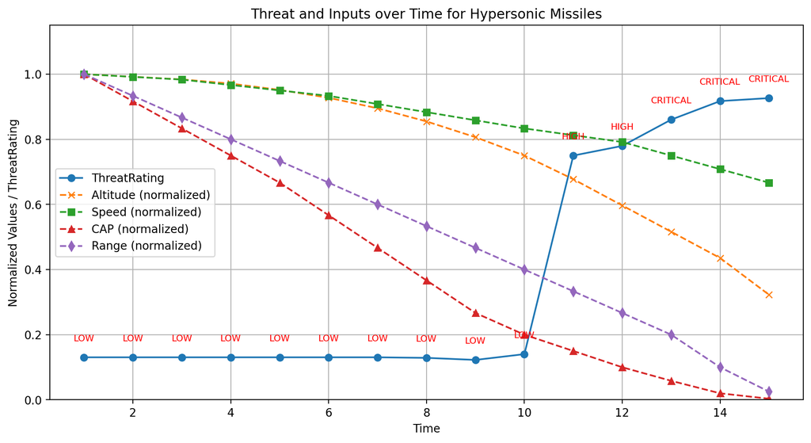

|  | time | Altitude_ft | Speed_kts | CAP_nm | Range_nm | ThreatRating | ThreatLevel |
| --- | --- | --- | --- | --- | --- | --- | --- |
| 0 | 1 | 62000 | 2400 | 60.0 | 600 | 0.130521 | LOW |
| 1 | 2 | 61500 | 2380 | 55.0 | 560 | 0.130521 | LOW |
| 2 | 3 | 61000 | 2360 | 50.0 | 520 | 0.130521 | LOW |
| 3 | 4 | 60200 | 2320 | 45.0 | 480 | 0.130521 | LOW |
| 4 | 5 | 59000 | 2280 | 40.0 | 440 | 0.130521 | LOW |
| 5 | 6 | 57500 | 2240 | 34.0 | 400 | 0.130521 | LOW |
| 6 | 7 | 55500 | 2180 | 28.0 | 360 | 0.130521 | LOW |
| 7 | 8 | 53000 | 2120 | 22.0 | 320 | 0.128824 | LOW |
| 8 | 9 | 50000 | 2060 | 16.0 | 280 | 0.122500 | LOW |
| 9 | 10 | 46500 | 2000 | 12.0 | 240 | 0.140238 | LOW |
| 10 | 11 | 42000 | 1950 | 9.0 | 200 | 0.750000 | HIGH |
| 11 | 12 | 37000 | 1900 | 6.0 | 160 | 0.779696 | HIGH |
| 12 | 13 | 32000 | 1800 | 3.5 | 120 | 0.860321 | CRITICAL |
| 13 | 14 | 27000 | 1700 | 1.2 | 60 | 0.917308 | CRITICAL |
| 14 | 15 | 20000 | 1600 | 0.2 | 15 | 0.926515 | CRITICAL |

```python
ShowSimulatedThreatRating("Hypersonic Missiles", "examples/hypersonic.csv")
```